# R Project 3 - Plotting

Richard Sauve

DATA 2401

Turn in the html and rmd for this project to blackboard, due Thursday April 8th before classtime. Make sure your name is on this document in the author spot and in the filename.

# Exploratory Plotting

In this assignment, we are going to be making exploratory and explanatory plots using the `msleep` dataset

```r
glimpse(msleep)
```

```
## Rows: 83
## Columns: 11
## $ name         <chr> "Cheetah", "Owl monkey", "Mountain beaver", "Greater shor~
## $ genus        <chr> "Acinonyx", "Aotus", "Aplodontia", "Blarina", "Bos", "Bra~
## $ vore         <chr> "carni", "omni", "herbi", "omni", "herbi", "herbi", "carn~
## $ order        <chr> "Carnivora", "Primates", "Rodentia", "Soricomorpha", "Art~
## $ conservation <chr> "lc", NA, "nt", "lc", "domesticated", NA, "vu", NA, "dome~
## $ sleep_total  <dbl> 12.1, 17.0, 14.4, 14.9, 4.0, 14.4, 8.7, 7.0, 10.1, 3.0, 5~
## $ sleep_rem    <dbl> NA, 1.8, 2.4, 2.3, 0.7, 2.2, 1.4, NA, 2.9, NA, 0.6, 0.8, ~
## $ sleep_cycle  <dbl> NA, NA, NA, 0.1333333, 0.6666667, 0.7666667, 0.3833333, N~
## $ awake        <dbl> 11.9, 7.0, 9.6, 9.1, 20.0, 9.6, 15.3, 17.0, 13.9, 21.0, 1~
## $ brainwt      <dbl> NA, 0.01550, NA, 0.00029, 0.42300, NA, NA, NA, 0.07000, 0~
## $ bodywt       <dbl> 50.000, 0.480, 1.350, 0.019, 600.000, 3.850, 20.490, 0.04~
```

1. First, you’re told that you should consider the `brainwt` and `bodywt` on the log10 scale. Create new variables using `mutate` that are the `log10()` of those two variables.

```r
msleep %>%
  mutate(brainwt_log = log10(brainwt), bodywt_log = log10(bodywt))
```

```
## # A tibble: 83 x 13
##    name   genus vore  order conservation sleep_total sleep_rem sleep_cycle awake
##    <chr>  <chr> <chr> <chr> <chr>              <dbl>     <dbl>       <dbl> <dbl>
##  1 Cheet~ Acin~ carni Carn~ lc                  12.1      NA        NA      11.9
##  2 Owl m~ Aotus omni  Prim~ <NA>                17         1.8      NA       7
##  3 Mount~ Aplo~ herbi Rode~ nt                  14.4       2.4      NA       9.6
##  4 Great~ Blar~ omni  Sori~ lc                  14.9       2.3       0.133   9.1
##  5 Cow    Bos   herbi Arti~ domesticated         4         0.7       0.667  20
##  6 Three~ Brad~ herbi Pilo~ <NA>                14.4       2.2       0.767   9.6
##  7 North~ Call~ carni Carn~ vu                   8.7       1.4       0.383  15.3
##  8 Vespe~ Calo~ <NA>  Rode~ <NA>                 7        NA        NA      17
##  9 Dog    Canis carni Carn~ domesticated        10.1       2.9       0.333  13.9
## 10 Roe d~ Capr~ herbi Arti~ lc                   3        NA        NA      21
## # ... with 73 more rows, and 4 more variables: brainwt <dbl>, bodywt <dbl>,
## #   brainwt_log <dbl>, bodywt_log <dbl>
```

2. Let’s start with a one variable plot, of a discrete (categorical) variable. I want to know the distribution of the variable `vore`, the diet type of the animals.

First, create a summary table using our dplyr tools: count how many animals are in each diet type.

```r
msleep %>%
  filter(!is.na(vore)) %>%
  group_by(vore) %>%
  count()
```

```
## # A tibble: 4 x 2
## # Groups:   vore [4]
##   vore        n
##   <chr>   <int>
## 1 carni      19
## 2 herbi      32
## 3 insecti     5
## 4 omni       20
```

Next, create a bar plot of that variable. What does this tell you? What’s the most common diet type? The least common?

These give you the same information, but in different ways! Which do you prefer?

```
Most common diet is herbivore and least common diet is insectivore.
The numbers are simpler and easier for me to understand.
```

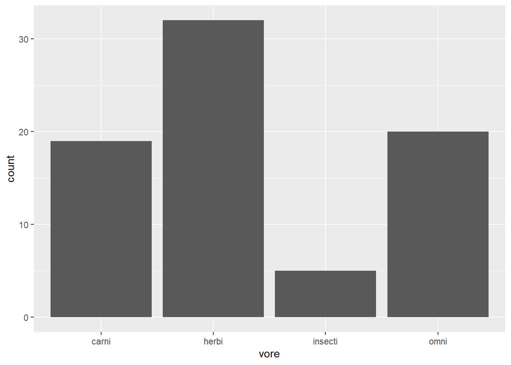

```r
msleep %>%
  filter(!is.na(vore)) %>%
  ggplot(aes(x = vore)) + geom_bar()
```

3. Now, a one variable plot, of a continous variable. This `sleep_total` variable seems interesting. Let’s see first how the overall distribution of the variable looks: use `geom_density()` to plot the emperical density of the variable. (hint: using the `fill = "some_color"` argument makes the density plots a little easier to read)

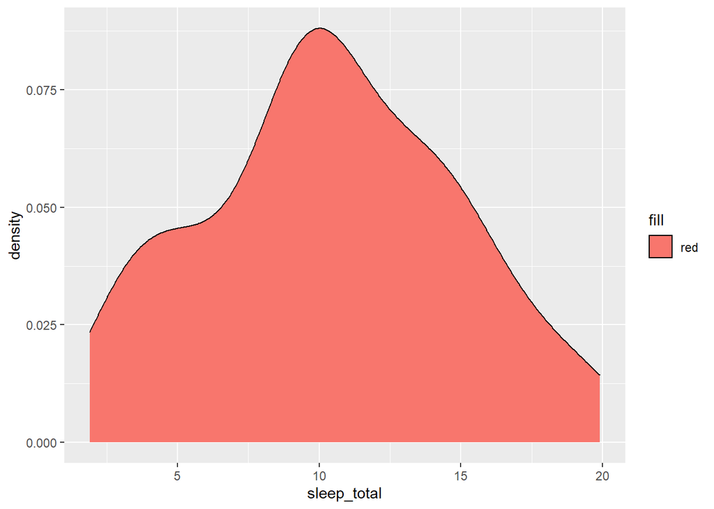

```r
msleep %>%
  ggplot(aes(x = sleep_total)) + geom_density(aes(fill = "red"))
```

4. A natural next question, using the two variables above is whether the distribution of the total sleep of the animals varies by diet. Use a graph to show this in some way.

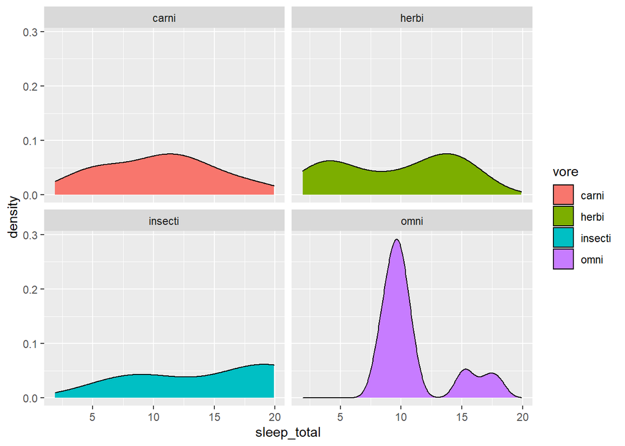

```r
msleep %>% filter(!is.na(vore)) %>%
  ggplot(aes(x = sleep_total, fill = vore)) + geom_density() + facet_wrap(~vore)
```

A little processing…. We want to remove the entries that have NA for the diet types, and we want to use order, but we want to remove orders that have less than 5 members to them. This isn’t always a good idea, but in this case we’re looking at broad picture and distribution between the groups. (Remember species, `genus`, family, `order`, class, phylum, kingdom, domain?)

```r
# look at the data, consider that we want to remove the NA and the small orders.
msleep %>% count(vore)
```

```
## # A tibble: 5 x 2
##   vore        n
##   <chr>   <int>
## 1 carni      19
## 2 herbi      32
## 3 insecti     5
## 4 omni       20
## 5 <NA>        7
```

```r
msleep %>% count(order)
```

```
## # A tibble: 19 x 2
##    order               n
##    <chr>           <int>
##  1 Afrosoricida        1
##  2 Artiodactyla        6
##  3 Carnivora          12
##  4 Cetacea             3
##  5 Chiroptera          2
##  6 Cingulata           2
##  7 Didelphimorphia     2
##  8 Diprotodontia       2
##  9 Erinaceomorpha      2
## 10 Hyracoidea          3
## 11 Lagomorpha          1
## 12 Monotremata         1
## 13 Perissodactyla      3
## 14 Pilosa              1
## 15 Primates           12
## 16 Proboscidea         2
## 17 Rodentia           22
## 18 Scandentia          1
## 19 Soricomorpha        5
```

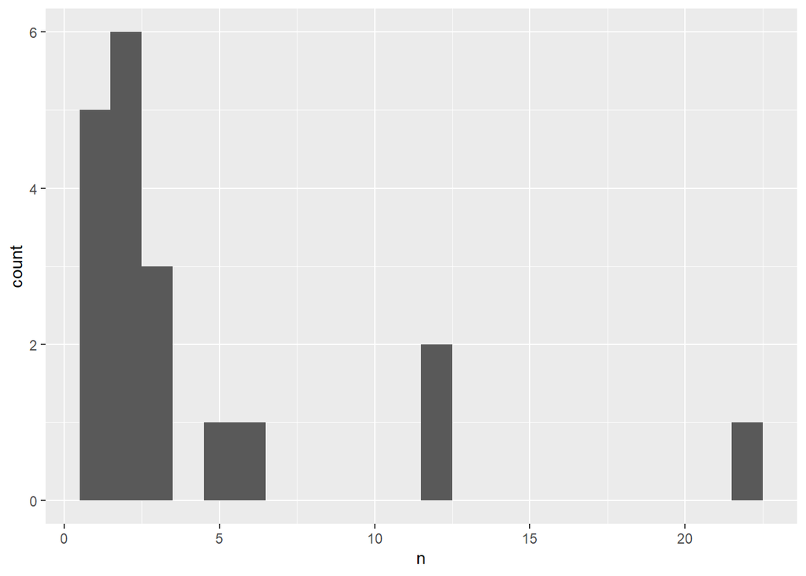

```r
# this graph is the scratch work I'd suggest doing to decide where to draw the cutoff
msleep %>% count(order) %>% ggplot(aes(x = n)) + geom_histogram(binwidth = 1)
```

Use `add_count`, the mutate version of `count`, to get an additional column that contains the count of the order of that row.

```r
msleep_data_ordervore <- msleep  %>%
    filter(!is.na(vore))         %>%  # Only cases with data for diet
    add_count(order)             %>%  # Find counts for each order, use ?add_count  for more info
    filter(n >= 5)
```

5. Two discrete/categorical variables: Let’s look back at our diet bar graph. Using our new subsetted data, add in a second discrete variable, `order`, using `fill` to see if each of the diets have a different distribution of the orders.

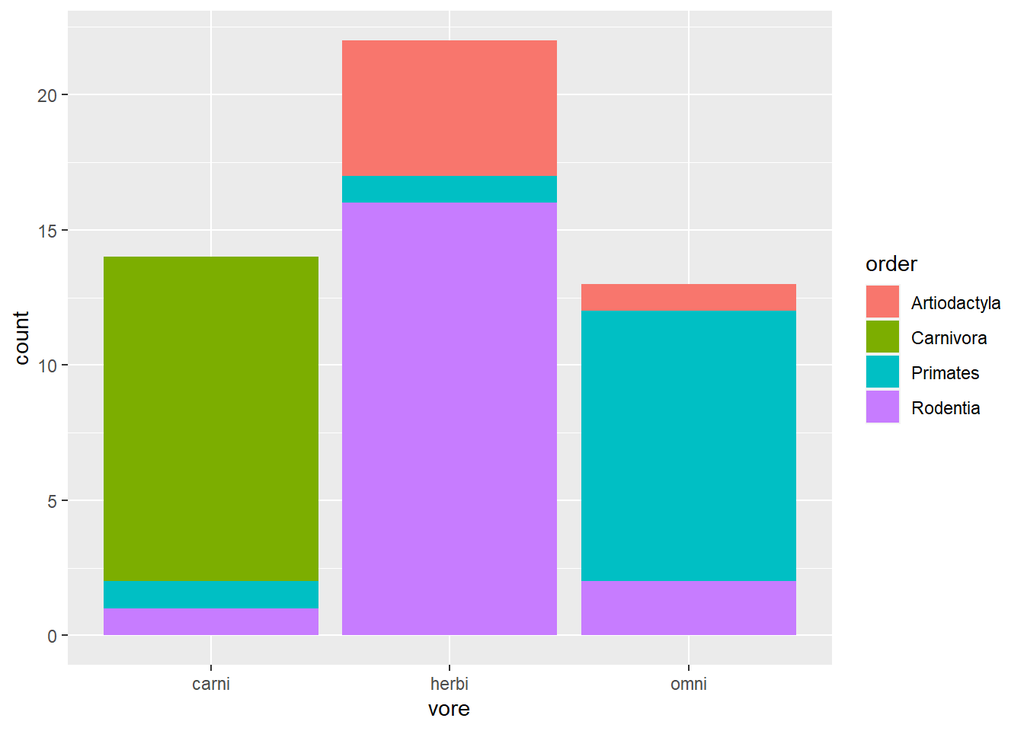

```r
msleep_data_ordervore %>%
  filter(!is.na(vore)) %>%
  ggplot(aes(x = vore, fill = order)) + geom_bar()
```

```r
glimpse(msleep_data_ordervore)
```

```
## Rows: 49
## Columns: 12
## $ name         <chr> "Cheetah", "Owl monkey", "Mountain beaver", "Cow", "North~
## $ genus        <chr> "Acinonyx", "Aotus", "Aplodontia", "Bos", "Callorhinus", ~
## $ vore         <chr> "carni", "omni", "herbi", "herbi", "carni", "carni", "her~
## $ order        <chr> "Carnivora", "Primates", "Rodentia", "Artiodactyla", "Car~
## $ conservation <chr> "lc", NA, "nt", "domesticated", "vu", "domesticated", "lc~
## $ sleep_total  <dbl> 12.1, 17.0, 14.4, 4.0, 8.7, 10.1, 3.0, 5.3, 9.4, 10.0, 12~
## $ sleep_rem    <dbl> NA, 1.8, 2.4, 0.7, 1.4, 2.9, NA, 0.6, 0.8, 0.7, 1.5, 2.0,~
## $ sleep_cycle  <dbl> NA, NA, NA, 0.6666667, 0.3833333, 0.3333333, NA, NA, 0.21~
## $ awake        <dbl> 11.9, 7.0, 9.6, 20.0, 15.3, 13.9, 21.0, 18.7, 14.6, 14.0,~
## $ brainwt      <dbl> NA, 0.0155, NA, 0.4230, NA, 0.0700, 0.0982, 0.1150, 0.005~
## $ bodywt       <dbl> 50.000, 0.480, 1.350, 600.000, 20.490, 14.000, 14.800, 33~
## $ n            <int> 12, 12, 19, 6, 12, 12, 6, 6, 19, 12, 19, 19, 12, 19, 12, ~
```

What would be the benefits of the fill/percentage graph? What are the drawbacks?

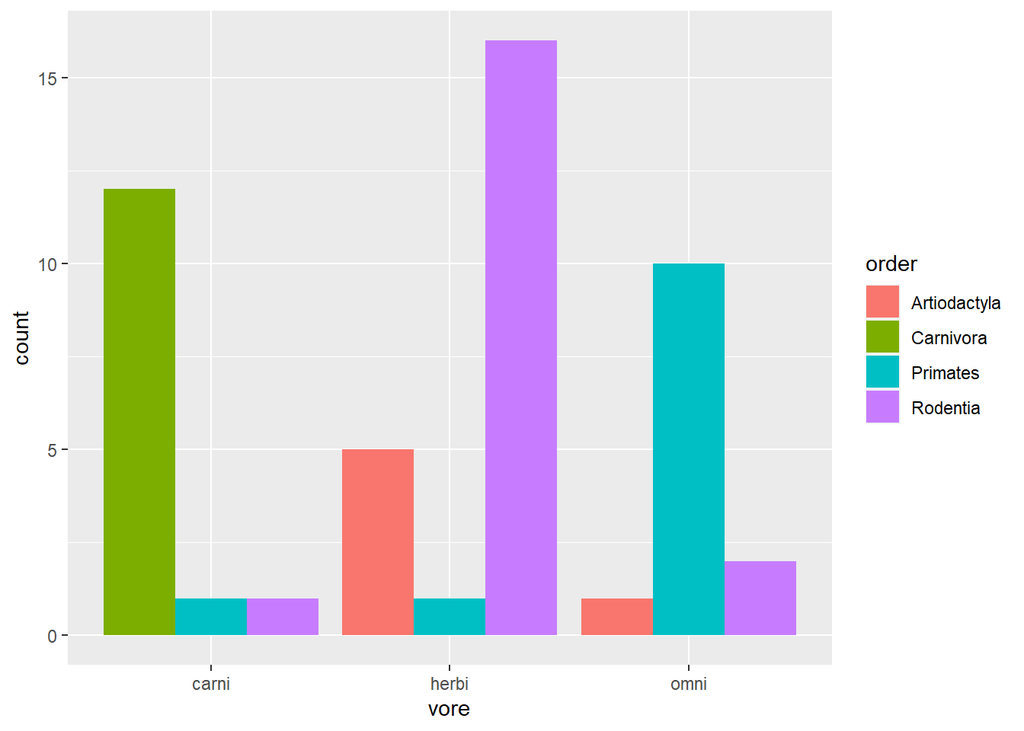

```r
msleep_data_ordervore %>%
  filter(!is.na(vore)) %>%
  ggplot(aes(x = vore, fill = order)) + geom_bar(position = "dodge")
```

6. Two continuous variables: Let’s finally look at those log10 weights! Still using our new msleep_data_ordervore, make a scatter plot with `log10_brainwt` on the x axis and `log10_bodywt` on the y axis.

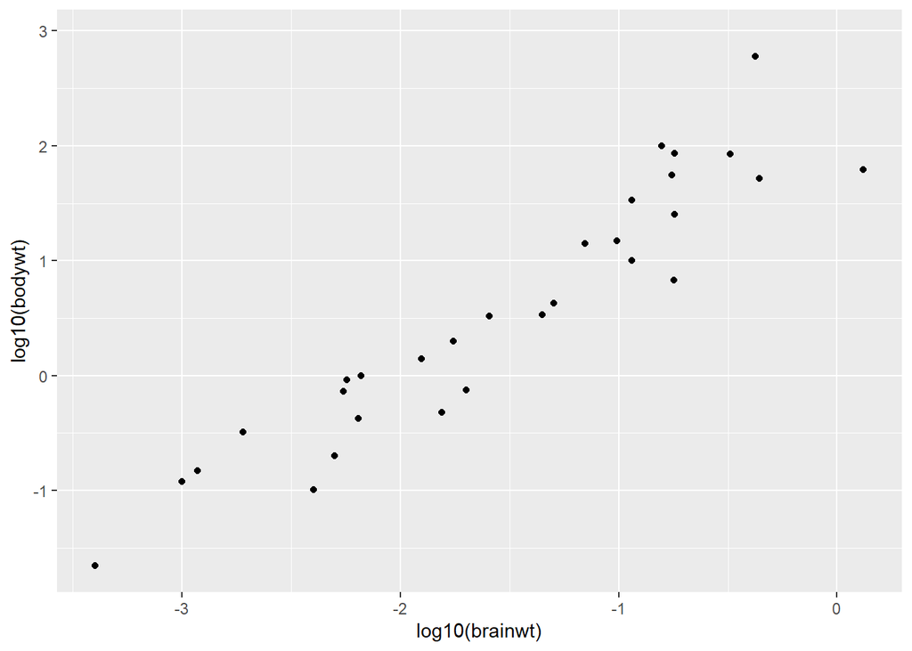

```r
msleep_data_ordervore %>% ggplot(aes(x = log10(brainwt), y = log10(bodywt))) + geom_point()
```

7. Add in categorical variables: make the shape encode the `order` of the animals, and the color encode their diet (`vore`). What can you now see about the herbivores?

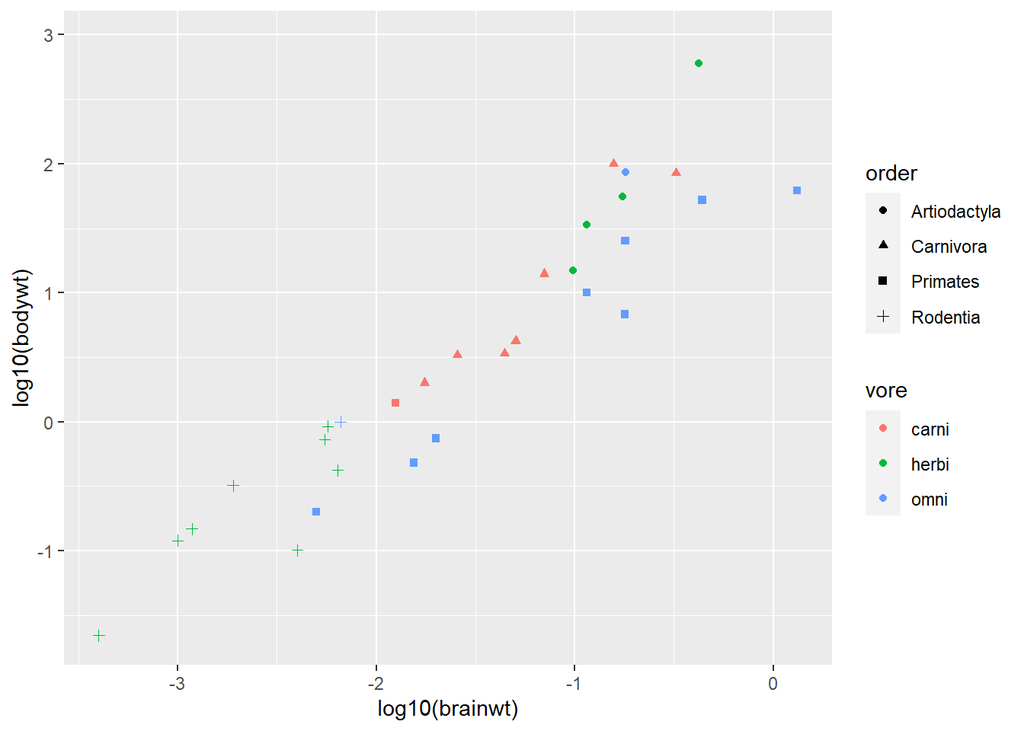

```r
msleep_data_ordervore %>% ggplot(aes(x = log10(brainwt), y = log10(bodywt), shape = order, color = vore)) + geom_point()
```

8. Give this plot a title, and rename the axes appropriately.

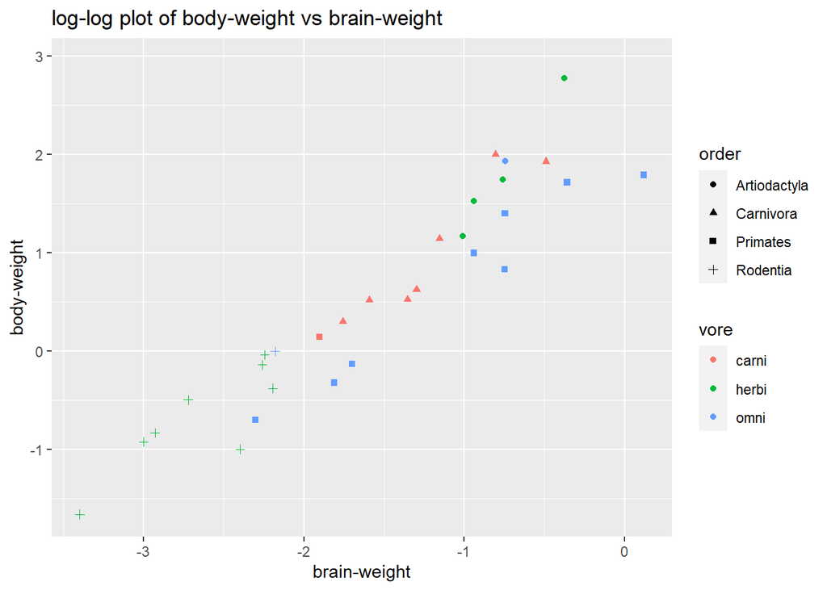

```r
msleep_data_ordervore %>% ggplot(aes(x = log10(brainwt), y = log10(bodywt), shape = order, color = vore)) + geom_point() + labs(x = "brain-weight", y = "body-weight", title = "log-log plot of body-weight vs brain-weight")
```